# 1. How to use a packaged `drake` workflow

Tiernan Martin

2019-05-16

The goal of `drakepkg` is to demonstrate how a [`drake`](https://ropensci.github.io/drake/) workflow can be organized as an R package. Users who are not yet familiar with [`drake`](https://ropensci.github.io/drake/) should review the package’s [User Manual](https://ropenscilabs.github.io/drake-manual/) before continuing with this vignette.

The following examples illustrate the way that [`drake`](https://ropensci.github.io/drake/) workflow’s can be reproduced when they’re included in an R package.

# 1 Simple Plan

This example borrows the `main` example from the [`drake`](https://ropensci.github.io/drake/) package documentation and recreates it within an R package.

The plan is included in `drakepkg` as a function:

```r
library(drakepkg) # devtools::install_packages("tiernanmartin/drakepkg")

get_example_plan_simple()
```

```
#> # A tibble: 5 x 2
#>   target     command
#>   <chr>      <expr>
#> 1 raw_data   readxl::read_excel(file_in("intdata/iris-internal.xlsx"))    ~
#> 2 ready_data dplyr::mutate(raw_data, Species = forcats::fct_inorder(Specie~
#> 3 hist       create_plot(ready_data)                                      ~
#> 4 fit        lm(Sepal.Width ~ Petal.Width + Species, ready_data)          ~
#> 5 report     write_html_report(hist, fit, knitr_in("documents/report-simpl~
```

Here are the steps needed to reproduce this plan:

1. Create a new [RStudio Project](https://support.rstudio.com/hc/en-us/articles/200526207-Using-Projects) or navigate to an empty working directory (not *required* but strongly recommended)
2. Copy the package’s directories and source code files into your working directory: `copy_drakepkg_files()`
3. Make the plan: `make(get_example_plan_simple())`
4. Access the plan’s targets using `drake` functions like `readd()` or `loadd()`
5. View the html documents produced by the workflow (see the `documents/` directory)

The first step is optional but strongly recommended; it is generally accepted as a best practice that data analysis projects should be [self-contained](https://www.tidyverse.org/articles/2017/12/workflow-vs-script/#self-contained-projects).

The second step is an important one. Most [`drake`](https://ropensci.github.io/drake/) plans interact with the user’s file system at some point, typically to read inputs or write outputs. `drakepkg`’s `inst/` directory contains the files and directories that are needed to successfully make `get_example_plan_simple()`. The `copy_drakepkg_files()` function copies the following directories from `drakepkg` into the user’s working directory:

```r
copy_drakepkg_files()
```

```
.
├── documents
├── extdata
└── intdata
    ├── R
    │   └── make-iris-internal.R
    └── iris-internal.xlsx
```

The third step is to make the plan:

```r
make(get_example_plan_simple())
```

```
#> target raw_data
#> target ready_data
#> target fit
#> target hist
#> target report
```

The worflow’s dependency graph can be displayed using `drake::vis_drake_graph()`:

```r
get_example_plan_simple() %>%
  drake_config() %>%
  vis_drake_graph()
```

[interactive chart not shown]

The final output of the plan above is the `report` target but any of the targets can be accessed using [`drake`](https://ropensci.github.io/drake/) functions like `loadd()` or `readd()`.

```r
# retrieve a target from the drake cache and inspect it
loadd(fit)
summary(fit)
```

```
#>
#> Call:
#> lm(formula = Sepal.Width ~ Petal.Width + Species, data = ready_data)
#>
#> Residuals:
#>      Min       1Q   Median       3Q      Max
#> -1.17017 -0.19105  0.00793  0.19173  0.85172
#>
#> Coefficients:
#>                   Estimate Std. Error t value Pr(>|t|)
#> (Intercept)        3.23587    0.05194  62.295  < 2e-16 ***
#> Petal.Width        0.78102    0.12121   6.443 1.59e-09 ***
#> Speciesversicolor -1.50150    0.14407 -10.422  < 2e-16 ***
#> Speciesvirginica  -1.84421    0.22399  -8.234 9.35e-14 ***
#> ---
#> Signif. codes:  0 '***' 0.001 '**' 0.01 '*' 0.05 '.' 0.1 ' ' 1
#>
#> Residual standard error: 0.3008 on 146 degrees of freedom
#> Multiple R-squared:  0.5335, Adjusted R-squared:  0.5239
#> F-statistic: 55.65 on 3 and 146 DF,  p-value: < 2.2e-16
```

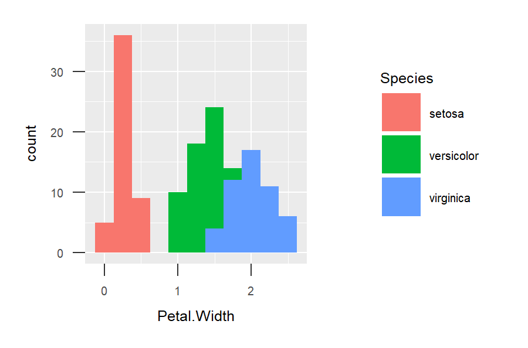

```r
# inspect a target without storing it in the local environment
readd(hist)
```

# 2 Plan With External Data

The second example builds on the first by introducing external data. The [`drake`](https://ropensci.github.io/drake/) cache automatically stores a copy of each target in a plan, but when the plan accessess data from an external source it’s a good idea to store a local copy of that data in addition to the cached copy.

The following plan downloads the `iris` dataset from a github repository and stores it in the `extdata` directory in the user’s working directory, like so:

```
.
├── documents
├── extdata
|   └── iris-external.xlsx <-- file downloaded in the plan is stored here
└── intdata
    ├── R
    │   └── make-iris-internal.R
    └── iris-internal.xlsx
```

Here is the plan:

```r
make(get_example_plan_external())
```

```
#> Unloading targets from environment:
#>   fit
#> target iris_ext_raw
#> target iris_int_raw
#> target iris_combined
#> target fit
#> target hist
#> target report
```

```r
get_example_plan_external() %>%
  drake_config() %>%
  vis_drake_graph()
```

[interactive chart not shown]

The visualization below shows that the new “`iris`” data is actually just random numbers:

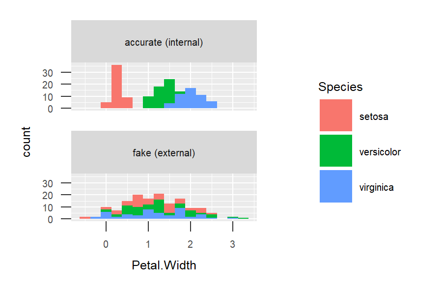

```r
readd(hist)
```

# 3 Plan With Open Science Framework Compendium

*(work in progress)*